# Introduction

The case at hand presents an intriguing problem that requires a detailed understanding of our clients and their challenges before diving into calculations. While the case's main focus is revenue, comprehending our clients' needs could offer alternative solutions. Any pricing solution we develop must, first and foremost, offer value to our clients. We are dealing with two distinct clients in this situation, each with unique needs and issues.

Our first client is the Rider: their primary goal is to travel from point A to B at the lowest cost possible, and they're highly dissatisfied when they can't find a match with a driver.

Our second client is the Driver: they aim to maximize their earnings from each ride, refusing any ride that isn't worth their time.

Upon reviewing our first pricing experiment and understanding these two groups, it's clear that both groups share a core problem: drivers are not receiving a fair price, which subsequently leads to riders being unable to find a match. Addressing this issue is critical.

This problem impacts our business on multiple fronts. The most evident one is the missed opportunity to cater to a customer who needs a ride but fails to find a match with a driver. Another possible concern is a decline in Rider Lifetime Value (LTV) due to increased churn rates in a no-match scenario. There is also concern for the LTV also dropping with a lower take rate, so we should be mindful of that.

Several questions where not answered from our first pricing experiments: How does the change in pricing affect the Driver CAC? Does it influence the driver churn rate? What is the ideal number of rides a driver should take per month? Is there a maximum amount of rides a driver can take?

Answering those questions can lead to new pricing strategies, but for now let's stick to the relation between Lyft's Take and Match Rate.

For this case study, I'll base my resolution on certain assumptions regarding the driver behaviour that should be validated later by further experiments.

Driver assumptions

- The driver's CAC is estimated at $500 (an average between the lowest and highest CAC)
- The driver churn is not affected by the changes in the lyft's take
- Our current amount of drivers can handle a 100% match rate scenario.

With these assumptions in place, let's run several scenarios to examine their outcomes. For the purposes of this study, I will not consider scenarios involving changes to the number of drivers and riders throught the year. While acquiring new customers or downsizing the driver fleet to maximize efficiency are valid strategies, they might introduce unwanted variables and noise into the data. However, I will include Rider LTV/CAC to assess growth viability for each scenario.

# 1 - Current state:

We will assess the net revenue in the current situation alongside other metrics such as Rider LTV. Assuming we have 10,000 total rider customers for a specific route in January, and with the existing match rate, 6,000 riders find matches, which equates to 60 drivers for this route. We are also going to assume a Rider CAC of $15 (average between lowest and highest CAC). This will define the constants we are going to use through this case.

Since each rider takes only one ride per month, the total number of rides is the same as the number of matched riders. To maintain these numbers for February, we must reacquire the same number of churned drivers and riders.

This is going to be used in our formula to calculate yearly revenue. We will take the amount of riders in a month and multiply by our lyft's take. We will then subtract that with the amount of churned users multiplied by the CAC. Finally, we will subtract the cost to reaquire drivers each month.

Let's start to build our code. I'll walk through the step by step I took for building it.

## 1.1 - Import Libraries

First, we import necessary Python libraries that provide functionalities we need. This includes *numpy* for numerical operations, *pandas* for data handling and manipulation, *seaborn* and *matplotlib.pyplot* for data visualization, and *sklearn.preprocessing* for standardizing data.

```python
import numpy as np
import pandas as pd
import seaborn as sns
import matplotlib.pyplot as plt
from sklearn.preprocessing import StandardScaler
```

## 1.2 - Define Constants

Constants related to customer behavior and business economics are set, such as churn rates and proportions of different user groups at different revenue levels.

```python
matched_churn_rate = 0.10
unmatched_churn_rate = 0.33
current_match_rate = 0.60
current_failed_rate = 0.40
experiment_match_rate = 0.93
experiment_failed_rate = 0.07
total_users = 10000
CAC = 15
reaquire_driver_cost = 1500
```

## 1.3 - Function to Calculate Values

We define a function *calculate_values* that takes in a value for lyft's take and calculates several metrics based on that and the previously defined constants. The metrics calculated include LTV (Life Time Value), LTV/CAC ratio, the weighted average churn rate, and yearly net revenue. This function also assumes the relation between match rate and lyft's take is linear since we only have two data points, but further experiments are needed to validate this behavior.

```python
def calculate_values(take_rate): #In this case, the function calculate_values takes in a value for monthly user revenue and calculates several metrics based on that and the previously defined constants.
    proportion1 = current_match_rate + (experiment_match_rate - current_match_rate) * (6 - take_rate) / 3
    proportion2 = current_failed_rate + (experiment_failed_rate - current_failed_rate) * (6 - take_rate) / 3
    weighted_average_churn_rate = (matched_churn_rate * proportion1) + (unmatched_churn_rate * proportion2)
    LTV = take_rate / weighted_average_churn_rate
    LTV_CAC_ratio = LTV / CAC
    matched_users = total_users * proportion1
    churned_users = total_users * weighted_average_churn_rate
    yearly_net_revenue = (take_rate * matched_users * 12) - (CAC * churned_users * 12) - (reaquire_driver_cost * 12)

    return LTV, LTV_CAC_ratio, weighted_average_churn_rate, yearly_net_revenue
```

With the function built, we can give it our prevailing lyft's take to access the current scenario:

```python
current_values = calculate_values(6)

print("Results:")
print("LTV (Lifetime Value):",current_values[0])
print("LTV/CAC Ratio:", current_values[1])
print("Weighted Average Churn Rate:", current_values[2])
print("Net Revenue:", "$", format(current_values[3], ",.2f"))
```

```
Results:
LTV (Lifetime Value): 31.25
LTV/CAC Ratio: 2.0833333333333335
Weighted Average Churn Rate: 0.192
Net Revenue: $ 68,400.00
```

# 1.4 - Pricing Experiment:

Now we are going to assess the net revenue from our pricing experiment for comparison with our prevailing wage scenario. Assuming the same constants defined earlier, we can use the same function with a a new value to find our annual net revenue of $107,820.00, although in this scenario we had a drop in rider LTV due to low lyft's take. We need to be mindful of this value for the growth of the product.

```python
experiment_values = calculate_values(3)
print("Results:")
print("LTV (Lifetime Value):", experiment_values[0])
print("LTV/CAC Ratio:", experiment_values[1])
print("Weighted Average Churn Rate:", experiment_values[2])
print("Net Revenue:", "$", format(experiment_values[3], ",.2f"))
```

```
Results:
LTV (Lifetime Value): 25.839793281653744
LTV/CAC Ratio: 1.722652885443583
Weighted Average Churn Rate: 0.11610000000000001
Net Revenue: $ 107,820.00
```

# 2 - Price Model:

We'll now predict changes in our performance based on different lyft's takes. Given that we already have a function that calculates the predicted net revenue and other metrics when given the lyft's take, all we need to do is create lots of different lyft's takes ranging from 1 to 6 and calculate the other metrics based on that. Then we plot on a graphic to see the results.

## 2.1 - Arrays for Calculation

Arrays of different lyft's takes are set up, and the previously defined function is used to calculate metrics for each of these rates. The results are split into separate arrays for easier handling later.

```python
take_rates = np.linspace(1, 6, 100)
results = np.array([calculate_values(tr) for tr in take_rates])
LTVs, LTV_CAC_ratios, weighted_average_churn_rates, net_revenue = results.T
```

## 2.2 - Create Dataframe for Visualization

We create a DataFrame where each column corresponds to one of the arrays of calculated metrics.

```python
data = pd.DataFrame({
    'Take_Rate': take_rates,
    'LTV': LTVs,
    'LTV_CAC_Ratio': LTV_CAC_ratios,
    'Weighted_Average_Churn_Rate': weighted_average_churn_rates,
    'Net_Revenue': net_revenue
})
```

## 2.3 - Visualize the Data

We use seaborn and matplotlib to create visualizations of each metric against the monthly user revenue. Each metric gets its own subplot.

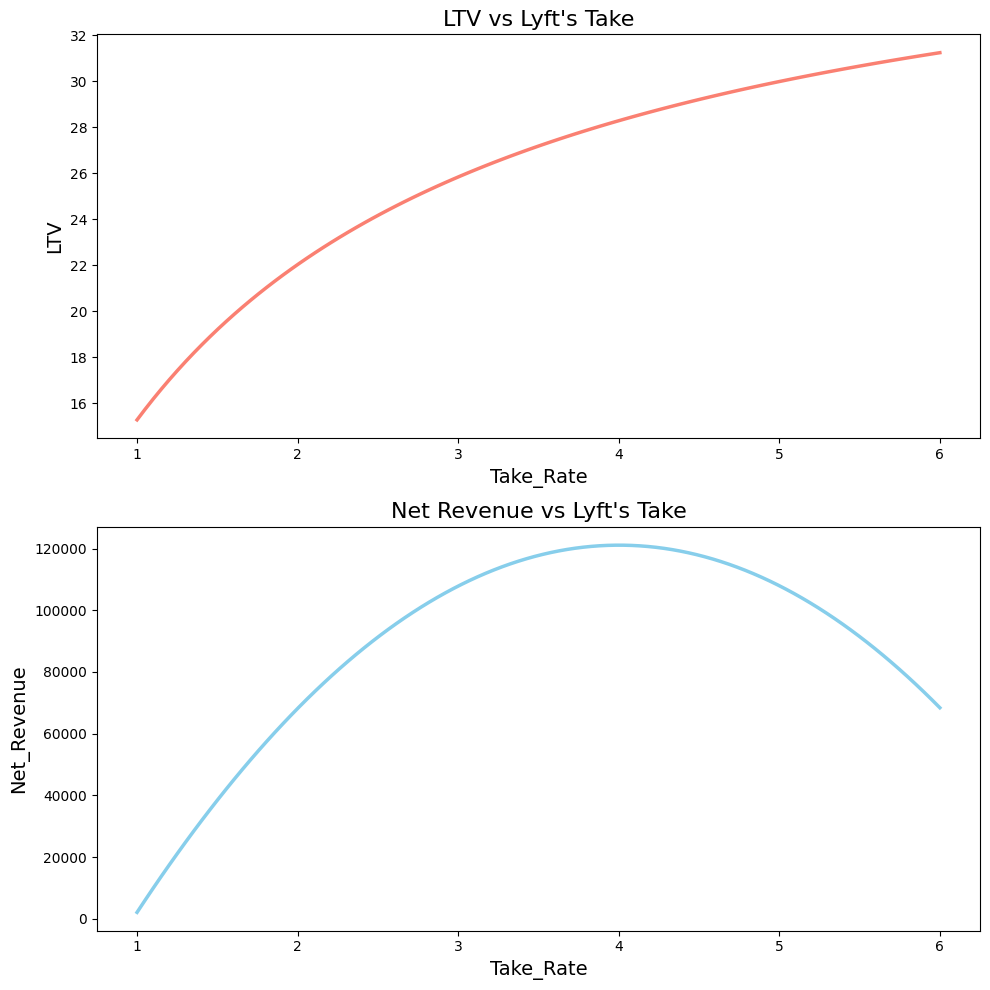

```python
plt.figure(figsize=(10, 10)) # Adjusting the overall figure size

variables = ['LTV', 'Net_Revenue']
titles = ["LTV vs Lyft's Take", "Net Revenue vs Lyft's Take"]
colors = ['salmon', 'skyblue'] # Defining colors for each plot

fig, axes = plt.subplots(2, 1, figsize=(10, 10)) # Adjusting the individual subplot size

for var, title, ax, color in zip(variables, titles, axes.flatten(), colors):
    sns.lineplot(data=data, x='Take_Rate', y=var, ax=ax, color=color, linewidth=2.5)
    ax.set_title(title, fontsize=16) # Larger font for the title
    ax.set_xlabel('Take_Rate', fontsize=14) # Larger font for x-axis label
    ax.set_ylabel(var, fontsize=14) # Larger font for y-axis label
    ax.grid(False) # Turn off grid

plt.tight_layout()
plt.show()
```

## 2.4 - Standardize Data

Before the final plot, the code makes a copy of the DataFrame and standardizes two of the columns ('LTV' and 'Net_Revenue'). Standardizing data means adjusting the values so they have a mean of 0 and a standard deviation of 1. This can make different datasets easier to compare visually.

```python
data_std = data.copy()
scaler = StandardScaler()
data_std[['LTV', 'Net_Revenue']] = scaler.fit_transform(data_std[['LTV', 'Net_Revenue']])
```

## 3.8 - Visualize Standardized Data

The final step is to plot the standardized data. This plot will show the standardized LTV and Net Revenue against the monthly user revenue. By standardizing these values, we can see how changes in the monthly user revenue affects these metrics on the same scale.

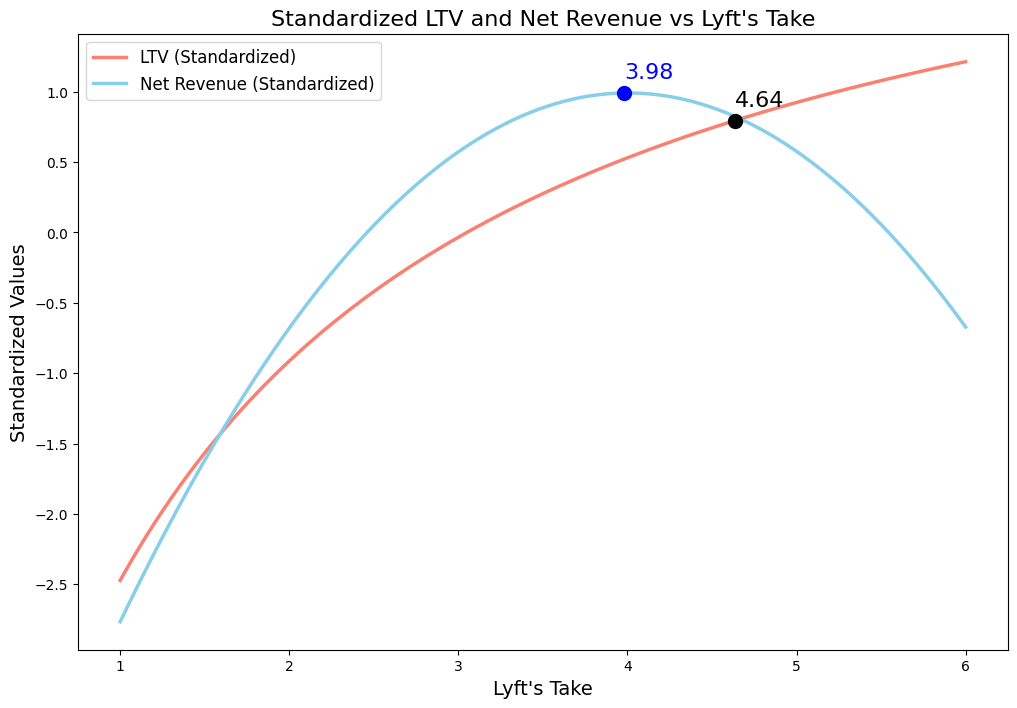

```python
plt.figure(figsize=(12, 8))

# Plot the standardized data with thicker lines and pastel colors
sns.lineplot(data=data_std, x='Take_Rate', y='LTV', label='LTV (Standardized)', linewidth=2.5, color='salmon')
sns.lineplot(data=data_std, x='Take_Rate', y='Net_Revenue', label='Net Revenue (Standardized)', linewidth=2.5, color='skyblue')

# Calculate intersection points
idx = np.argwhere(np.diff(np.sign(data_std['LTV'] - data_std['Net_Revenue'])) != 0).reshape(-1) + 0

# Drop the lower intersection
idx = idx[data_std['LTV'][idx].argsort()][-1:]

# Plot intersection points with a larger marker size
plt.plot(data_std['Take_Rate'][idx], data_std['LTV'][idx], 'ko', markersize=10)

# Find the highest point on the Net Revenue line
idx_max_profit = data_std['Net_Revenue'].idxmax()
plt.plot(data_std['Take_Rate'][idx_max_profit], data_std['Net_Revenue'][idx_max_profit], 'bo', markersize=10)

# Add labels for intersection points, slightly above the intersection point, with a larger font size
for i in idx:
    plt.text(data_std['Take_Rate'][i], data_std['LTV'][i] + 0.1, f'{data_std["Take_Rate"][i]:.2f}', color='black', fontsize=16)

# Add label for the highest point on the Net Revenue line, slightly to the right of the point, with a larger font size
plt.text(data_std['Take_Rate'][idx_max_profit], data_std['Net_Revenue'][idx_max_profit] + 0.1, f'{data_std["Take_Rate"][idx_max_profit]:.2f}', color='blue', fontsize=16)

# Modify the plot to have no grid and change the title, xlabel and ylabel
plt.title("Standardized LTV and Net Revenue vs Lyft's Take", fontsize=16)
plt.xlabel("Lyft's Take", fontsize=14)
plt.ylabel('Standardized Values', fontsize=14)
plt.legend(fontsize=12)
plt.grid(False)
plt.show()
```

By looking at this plot, we see two points marked in the graph. The first one (in blue) indicates the predicted Lyft's Take that yields the highest Net Revenue, which should be aproximately 4. We also see that there is a point of intersection where we can find a good amount of revenue while maintaining a good LTV. This is crucial for the growth of the product. In the code bellow we can see the difference in yearly profit for each lyft's take.

```python
print("Results:")

# Find closest lyft's take to 4.64 in the DataFrame
closest_take_rate = data['Take_Rate'].iloc[(data['Take_Rate']-4.64).abs().argsort()[:1]]

# Get the corresponding LTV and Net Revenue
corresponding_LTV = data.loc[closest_take_rate.index, 'LTV'].values[0]
corresponding_Net_Revenue = data.loc[closest_take_rate.index, 'Net_Revenue'].values[0]

print(f"For the lyft's take of {closest_take_rate.values[0]:.2f}, the corresponding LTV is {corresponding_LTV:.2f} and the yearly profit is ${corresponding_Net_Revenue:,.2f}")

# Find closest lyft's take to 4 in the DataFrame
closest_take_rate = data['Take_Rate'].iloc[(data['Take_Rate']-4).abs().argsort()[:1]]

# Get the corresponding LTV and Net Revenue
corresponding_LTV = data.loc[closest_take_rate.index, 'LTV'].values[0]
corresponding_Net_Revenue = data.loc[closest_take_rate.index, 'Net_Revenue'].values[0]

print(f"For the lyft's take of {closest_take_rate.values[0]:,.2f}, the corresponding LTV is {corresponding_LTV:,.2f} and the yearly profit is ${corresponding_Net_Revenue:,.2f}")
```

```
Results:
For the lyft's take of 4.64, the corresponding LTV is 29.44 and the yearly profit is $115,772.73
For the lyft's take of 3.98, the corresponding LTV is 28.25 and the yearly profit is $121,073.40
```

# Scenario 4 - Dynamic CAC

In this scenario, we will assume that CAC also changes according to the churn rate. This assumption comes from the fact that the CAC is sensitive to the rate of acquisition. So instead of assuming the average CAC of 15, let's assume that our highest churn rate (which means highest acquisition rate to maintain current standards) equals to the highest CAC (20) and our lowest churn rate equals to the lowest CAC (10). Those values are arbitrary, but should provide us an insight into how these affect our LTVs and projected revenue.

We will basically reuse the code above, but adding the new way to calculate the CAC. We'll assume it also behaves linearly. Code was hidden to make document more readable, but can be checked in the Colab link.

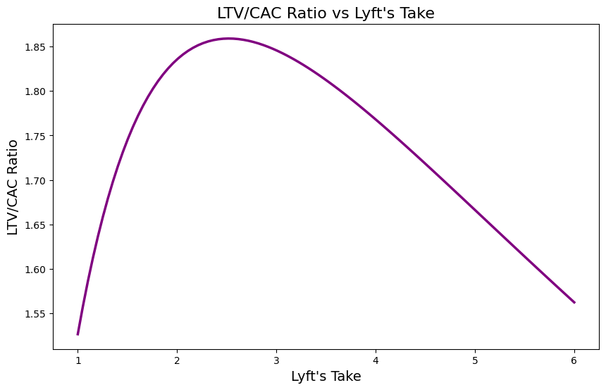

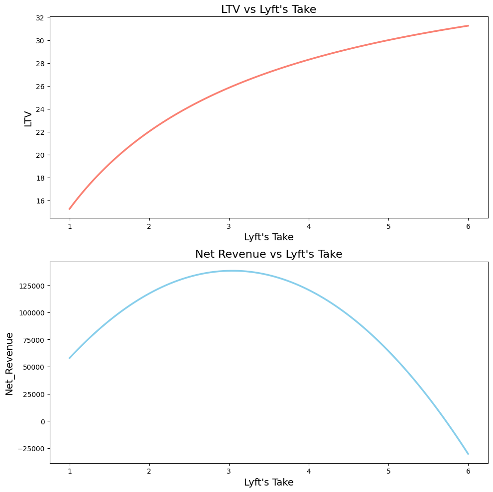

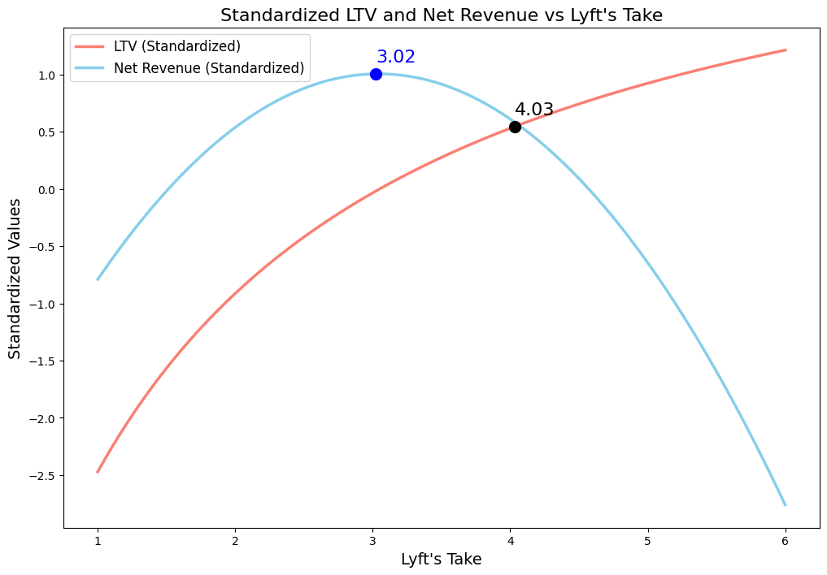

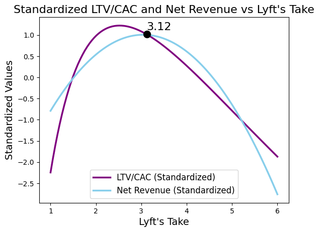

With this correlation between churn and CAC prices, the strategy changes. We can see that not only does the higher lyft's take results in a a drop in net revenue, it also drops our LTV/CAC dramaticaly. For this scenario, the lyft's take that results in the highest revenue is 3, and the optimal point for LTV and Profit would be a lyft's take of aproximately 4. If we look at LTV/CAC, then the value also becomes close to 3.

# Next steps

It is clear that lowering the lyft's take is benefitial to the business and the customers, so we should drop them immediately. Given that we already have data on the lyft's take of 3 (the value indicated as the highest net revenue by the dynamic CAC scenario), we should use a lyft's take of 4 (the value indicated with an average CAC of 15). This way we can validate if our assumptions of the match rate being linear are correct, while also observing possible changes in CAC and adjusting as we observe the results.

After that, I see an opportunity for a dynamic lyft's take to be implemented to further maximize revenue potential. This could be done by a matching algorithm or an auction system and can be validated by an A/B testing experiment.